# Project proposal

Passionate Puffins

```r
#install.packages("tidyverse")
library(tidyverse)
library(broom)
library(readxl)
```

## 1. Introduction

Our data comes from all High Schools in the Androscoggin Area (this will be updated for specificity once we have specific school names). They surveyed their students about drug use, alcohol consumption, smoking habits, eating habits, home lives, and how much support they felt they were recieving from their parents. We will be using this data to evaluate the health of students at Androscoggin County High school compared to how much support they feel they are recieving from their parents. We would also like to compare the differences in support and unhealthy behavior between gender (i.e.: are female students more likely to smoke/drink/do drugs if they have low familial support than male students?).

In a study by the NIH (https://pmc.ncbi.nlm.nih.gov/articles/PMC8656923/), the association between parental support and the rate of smoking in youth was found to be positive. It will be interesting to compare these results to our findings about the relationship between support and unhealthy behavior.

Research Question: How big a role do home support systems play in the health of Androscoggin youth?

## 2. Data

```r
Drinking_data <- read_xlsx("../data/How many times in the past year (12 months) have you been drunk or high at school? (hn126) Percentage of students who answered at least 1 time.xlsx")
#I don't have access to this data file to rename it. (Katie)

family_support_data <- read.csv("/cloud/project/data/love_support_family.csv")

Drinking_vs_family <- full_join(Drinking_data,
                              family_support_data,
                              by = "Grade")
```

```r
Drinking_data <- Drinking_data |>
  rename("Percent Total Age" = "Percent Total Ague")
```

```r
view(family_support_data)
view(Drinking_data)
```

```r
glimpse(Drinking_data)
```

```
## Rows: 9
## Columns: 10
## $ Age                     <chr> NA, NA, "<=14", "15.0", "16.0", "17.0", ">=18"…
## $ `Percent Total Age`     <dbl> 0.125, NA, 0.108, 0.132, 0.116, 0.130, 0.140, …
## $ `Female Age`            <dbl> 0.115, NA, 0.086, 0.134, 0.112, 0.104, 0.152, …
## $ `Male Age`              <dbl> 0.136, NA, 0.142, 0.132, 0.123, 0.158, 0.130, …
## $ Grade                   <chr> NA, NA, "Grade 9", "Grade 10", "Grade 11", "Gr…
## $ `Percent Total Grade`   <dbl> NA, NA, 0.109, 0.115, 0.142, 0.133, NA, NA, NA
## $ `Female by Grade`       <dbl> NA, NA, 0.130, 0.091, 0.119, 0.122, NA, NA, NA
## $ `Male by Grade`         <dbl> NA, NA, 0.083, 0.147, 0.165, 0.144, NA, NA, NA
## $ Race                    <chr> NA, NA, "American Indian/Alaskan Native", "Asi…
## $ `Percent Total By Race` <chr> NA, NA, "0.218", "*", "0.048", "0.305", "*", "…
```

```r
glimpse(family_support_data)
```

```
## Rows: 12
## Columns: 30
## $ Age             <chr> "14 or younger", "15", "16", "17", "18 or older", "Tot…
## $ Age..           <chr> "79.80%", "77.20%", "81.80%", "79.70%", "76.00%", "79.…
## $ Age.CI          <chr> "(76.0%-83.5%)", "(75.3%-79.2%)", "(76.9%-86.6%)", "(7…
## $ Age.N           <chr> "489", "845", "871", "718", "322", "3,250", "", "", ""…
## $ Female.Age..    <chr> "81.60%", "76.00%", "82.50%", "83.40%", "77.30%", "80.…
## $ Female.Age.CI   <chr> "(70.7%-92.5%)", "(69.2%-82.8%)", "(79.6%-85.3%)", "(7…
## $ Female.Age.N    <chr> "306", "444", "467", "388", "157", "1,761", "", "", ""…
## $ Male.Age..      <chr> "77.70%", "78.70%", "81.90%", "75.80%", "74.70%", "78.…
## $ Male.Age.CI     <chr> "(65.2%-90.2%)", "(74.3%-83.2%)", "(72.2%-91.6%)", "(6…
## $ Male.Age.N      <chr> "181", "397", "400", "330", "165", "1,476", "", "", ""…
## $ Grade           <chr> "Grade 9", "Grade 10", "Grade 11", "Grade 12", "", "",…
## $ Grade..         <chr> "79.20%", "78.50%", "80.60%", "79.00%", "", "", "", ""…
## $ Grade.CI        <chr> "(76.6%-81.9%)", "(73.9%-83.2%)", "(78.3%-82.9%)", "(7…
```

[output cut: 17 more lines]

```r
dim(Drinking_data)
```

```
## [1]  9 10
```

```r
dim(Drinking_vs_family)
```

```
## [1] 17 39
```

## 3. Data analysis plan

Based on our research question, we plan to compare various indications of good support systems against indications of unhealthy youth behavior. For example, we plan to create a visualization and analysis to contrast how much a child feels supported by their parents against how easy it would be for them to attain drugs. How effective is a good familial support system (how much the student feels supported by their parents) in preventing unhealthy behavior (buying/using drugs)?

To answer the question effectively, we will create multiple visualizations similar to this, including:

- How many times in the past year (12 months) have you been drunk or high in school (percentage of students who answered one time or more)? vs. Students who answered ‘Very or often’ or ‘Extremely or almost always’ to ‘I have parents who are good at talking with me about things.’
- During the past 30 days, on how many days did you smoke cigars, cigarillos, or little cigars (percentage of students who answered ‘at least one day’)? vs. Students who answered ‘Very or often’ or ‘Extremely or almost always’ to ‘I have parents who are good at talking with me about things.’
- During the past 30 days, how many times did you drive a car or other vehicle when you had been drinking alcohol (among students who drove a car or other vehicle during the past 30 days, the percentage who answered at least 1 time)? vs. Percentage of students who answered ‘Very or often’ or ‘Extremely or almost always’ to ‘I have a family that gives me love and support.’

We plan to categorize and consider variables within the datasets such as grade, age, race, and gender. We will likely use a bar graph similar to the one below to visualize the patterns between the data.

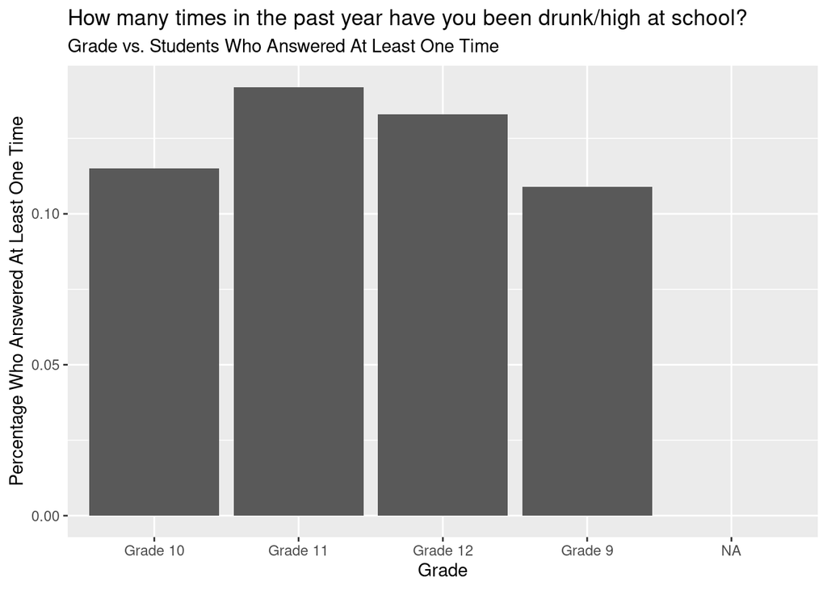

```r
Drinking_data |>
  ggplot(aes(x = Grade, y = `Percent Total Grade`)) +
  geom_col(na.rm = TRUE) +
  labs(x = 'Grade',
       y = 'Percentage Who Answered At Least One Time',
       title = 'How many times in the past year have you been drunk/high at school?',
       subtitle = "Grade vs. Students Who Answered At Least One Time")
```

## 4. Data Ethics Review